# Data Processing

John Zhuang

2024-05-13

```r
library(utils)
library(dplyr)
library(knitr)
```

# Read in raw data

```r
colData = read.table("data/raw/accmatched_colData.tsv")
gistict = read.table("data/raw/accmatched_gistict.tsv")
#META_0 = read.table("data/raw/accmatched_META_0.tsv")
miRNASeqGene = read.table("data/raw/accmatched_miRNASeqGene.tsv")
Mutations = read.table("data/raw/accmatched_Mutations.tsv")
RNASeq2GeneNorm = read.table("data/raw/accmatched_RNASeq2GeneNorm.tsv")
RPPAArray = read.table("data/raw/accmatched_RPPAArray.tsv")
sampleMap = read.table("data/raw/accmatched_sampleMap.tsv")
```

# Merge days_to_death and days_to_follow_up into a single variable event_time

```r
colData$event_time = case_when(colData$vital_status == 1 ~ colData$days_to_death,
                     colData$vital_status == 0 ~ colData$days_to_last_followup)
```

## For colData, only a small subset of the variables are needed

days_to_death and days_to_follow_up are removed as event_time has replaced them.

```r
col.sel = names(colData)[c(1:3, 31, 6:10,12:18)]
col.sel
```

```
##  [1] "patientID"             "years_to_birth"        "vital_status"
##  [4] "event_time"            "tumor_tissue_site"     "pathologic_stage"
##  [7] "pathology_T_stage"     "pathology_N_stage"     "gender"
## [10] "radiation_therapy"     "histological_type"     "residual_tumor"
## [13] "number_of_lymph_nodes" "race"                  "ethnicity"
## [16] "Histology"
```

```r
s.colData = colData[, col.sel]
```

## Report missing values for all Metadata values:

```r
missing.vals = as.data.frame(colSums(is.na(s.colData)))
names(missing.vals) = "# of Missing Values"
missing.vals.meta = missing.vals[-c(1,3,4), , drop=F] # Exclude patientID and (survival) response variables.
kable(missing.vals.meta[order(missing.vals.meta$`# of Missing Values`, decreasing = T), , drop=F],
      caption = "Missing values per metadata variable")
```

Missing values per metadata variable

|  | # of Missing Values |
| --- | --- |
| number_of_lymph_nodes | 24 |
| ethnicity | 22 |
| race | 8 |
| residual_tumor | 1 |
| years_to_birth | 0 |
| tumor_tissue_site | 0 |
| pathologic_stage | 0 |
| pathology_T_stage | 0 |
| pathology_N_stage | 0 |
| gender | 0 |
| radiation_therapy | 0 |
| histological_type | 0 |
| Histology | 0 |

# Change colnames to patient IDs

```r
col.to.patient = function(df) {
  col.orig = names(df)
  df.name = deparse(substitute(df)) #variable name of dataframe
  df.sel = sampleMap[sampleMap$assay == df.name, ]
  col.new = vector(mode="character", length=length(col.orig))
  for (i in 1:length(col.orig)) {
    c = col.orig[i]
    c = gsub(".", "-", c, fixed=T)
    p = df.sel[df.sel$colname == c,]$primary
    #print(c)
    col.new[i] = p
  }

  names(df) = col.new
  df
}
```

```r
table(sampleMap$assay)
```

```
##
##         gistict    miRNASeqGene       Mutations RNASeq2GeneNorm       RPPAArray
##              43              43              43              43              43
```

```r
p.RNASeq2GeneNorm = col.to.patient(RNASeq2GeneNorm)
p.gistict = col.to.patient(gistict)
p.RPPAArray = col.to.patient(RPPAArray)
p.Mutations = col.to.patient(Mutations)
p.miRNASeqGene = col.to.patient(miRNASeqGene)
```

# Rename rownames so that they don’t conflict when joined

## Extract list of unique gene names before renaming (for pathway analysis purposes)

```r
genes.RNASeq2GeneNorm = rownames(p.RNASeq2GeneNorm)
genes.gistict = rownames(p.gistict)
genes.RPPAArray = rownames(p.RPPAArray)
genes.Mutations = rownames(p.Mutations)
genes.all = c(genes.RNASeq2GeneNorm, genes.gistict, genes.RPPAArray, genes.Mutations)
genes.unique = unique(genes.all)
saveRDS(genes.unique, file = "data/derived/unique_gene_names.rds")
```

```r
rename.gene = function(df, abbrev, row=T) {
  if (row) {
    for (i in 1:length(row.names(df))) {
      row.names(df)[i] = paste(c(row.names(df)[i], abbrev), collapse = ".")
    }
  }
  df
}
```

```r
r.RNASeq2GeneNorm = rename.gene(p.RNASeq2GeneNorm, "R2Gn")
r.gistict = rename.gene(p.gistict, "g")
r.RPPAArray = rename.gene(p.RPPAArray, "RPPA")
r.Mutations = rename.gene(p.Mutations, "M")
```

# Check for identical rows (variables) in numeric data

Identical variable rows make data redundant and causes Xtune to fail.

We will check if any columns in the 3 numeric data frames are identical.

```r
check.identical.rows = function(data) {
  for (i in 1:(nrow(data) -1)) {
    for (j in (i+1):nrow(data)) {
      if (all(data[i,] == data[j,])) {
        print(rownames(data)[i])
        print(i)
        print(rownames(data)[j])
        print(j)
      }
    }
  }
}
```

```r
check.identical.rows(p.miRNASeqGene)
```

```
## [1] "hsa-mir-517a"
## [1] 364
## [1] "hsa-mir-517b"
## [1] 365
```

```r
check.identical.rows(r.RNASeq2GeneNorm)
check.identical.rows(r.RPPAArray)
```

Only the rows “**hsa-mir-517a**” and “**hsa-mir-517b**” in the **miRNASeqGene** dataframe are identical to each other.

“**hsa-mir-517b**” will be removed from the data to avoid duplicates.

```r
nodupe.miRNASeqGene = p.miRNASeqGene[rownames(p.miRNASeqGene) != "hsa-mir-517b",]
```

# Standardize Numerical Data

(Convert to mean 0, sd 1)

```r
sd.RNASeq2GeneNorm = scale(sqrt(r.RNASeq2GeneNorm)) # Sqrt then Standardized

# log transformed, +epsilon added to avoid log(0)
sd.miRNASeqGene = scale(log2(nodupe.miRNASeqGene + 0.01)) # Log then Standardize

sd.RPPAArray = scale(r.RPPAArray)
#apply(sd.RNASeq2GeneNorm, 1, mean)
#apply(sd.miRNASeqGene, 1, mean)
```

## Plot Pre and Post-standardization

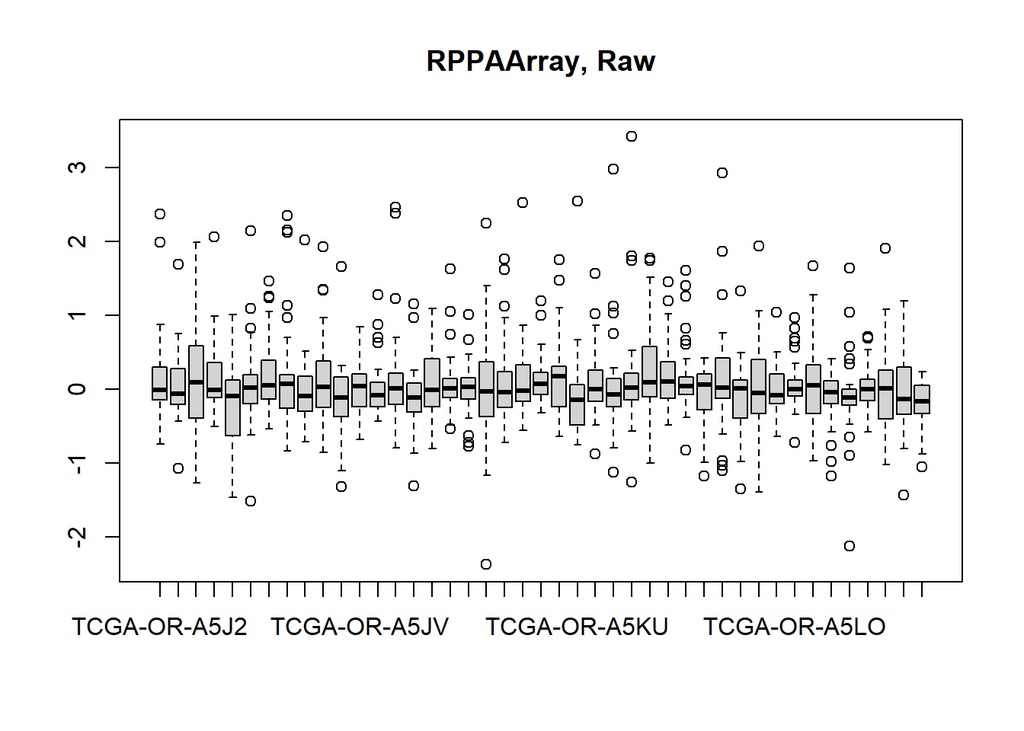

```r
boxplot(r.RPPAArray, main = "RPPAArray, Raw")
```

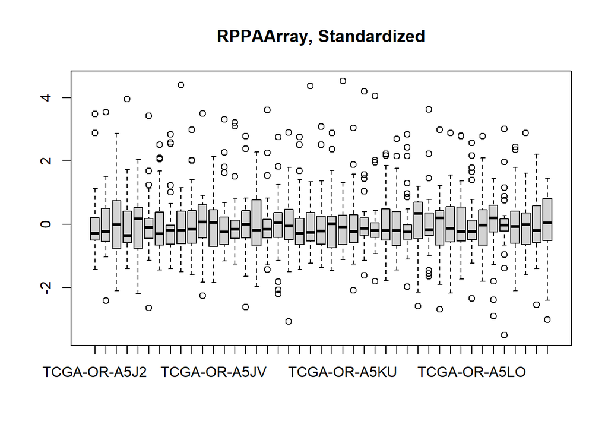

```r
boxplot(sd.RPPAArray, main = "RPPAArray, Standardized")
```

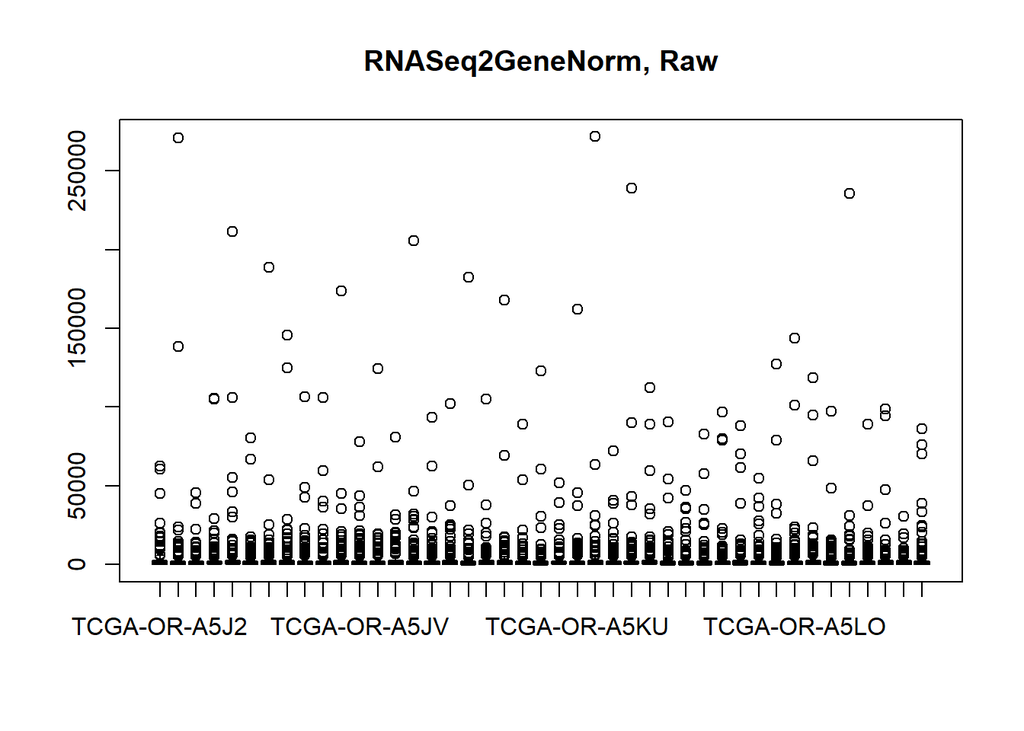

```r
boxplot(r.RNASeq2GeneNorm, main = "RNASeq2GeneNorm, Raw")
```

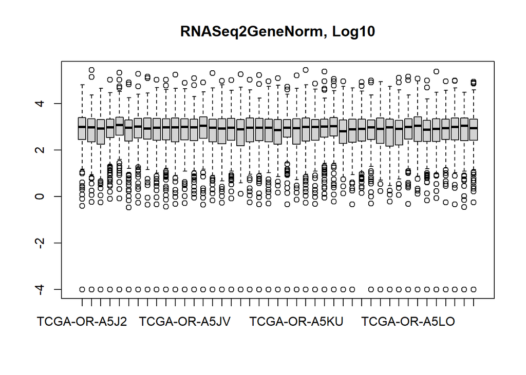

```r
boxplot(log10(r.RNASeq2GeneNorm + 0.0001), main = "RNASeq2GeneNorm, Log10")
```

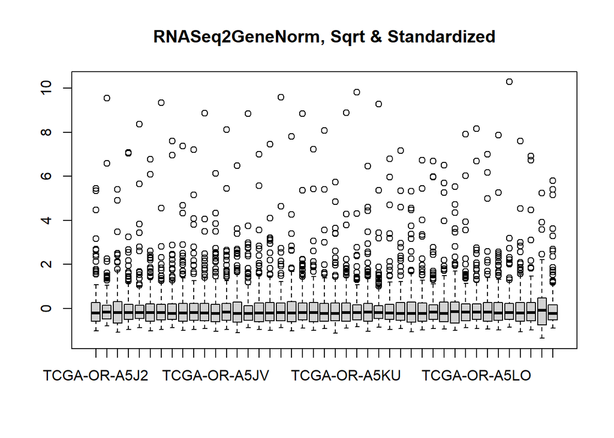

```r
boxplot(sd.RNASeq2GeneNorm, main = "RNASeq2GeneNorm, Sqrt & Standardized")
```

```r
#boxplot(scale(r.RNASeq2GeneNorm), main = "RNASeq2GeneNorm, Standardized only")
#boxplot(scale(sqrt(r.RNASeq2GeneNorm)), main = "RNASeq2GeneNorm, Sqrt & Standardized")
```

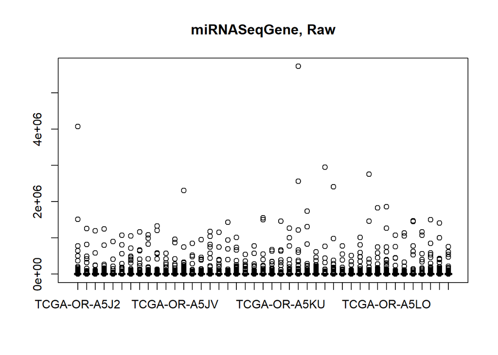

```r
boxplot(nodupe.miRNASeqGene, main = "miRNASeqGene, Raw")
```

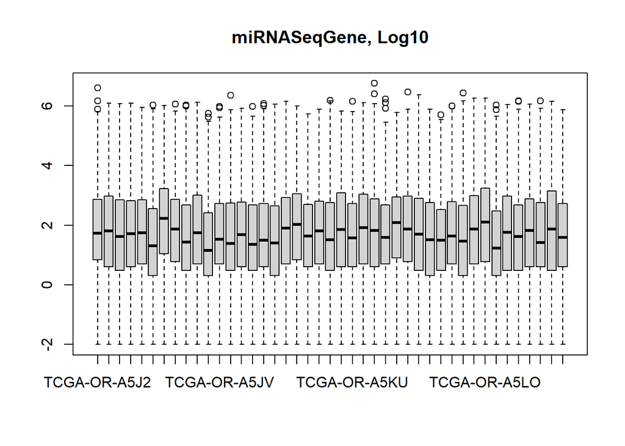

```r
boxplot(log10(nodupe.miRNASeqGene + 0.01), main = "miRNASeqGene, Log10")
```

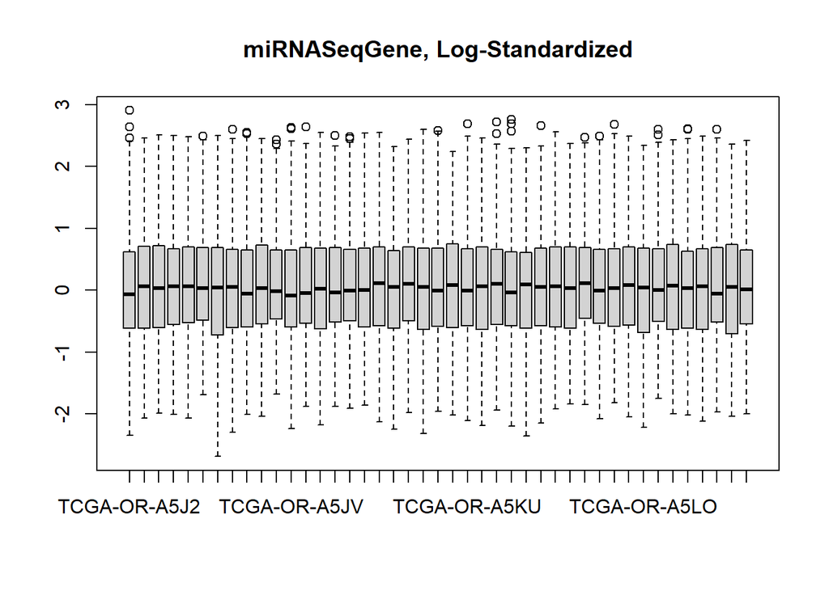

```r
boxplot(sd.miRNASeqGene, main = "miRNASeqGene, Log-Standardized")
```

# Transpose and merge data (for Ridge/Lasso)

```r
t4merge = function(df) {
  t.df = as.data.frame(t(as.matrix(df))) #transpose while in matrix form
  #t.df$patientID = rownames(t.df) #Explicitly write rownames as a column for later data merging
  t.df
}
```

```r
t.RNASeq2GeneNorm = t4merge(sd.RNASeq2GeneNorm)
t.gistict = t4merge(r.gistict)
t.RPPAArray = t4merge(sd.RPPAArray)
t.Mutations = t4merge(r.Mutations)
t.miRNASeqGene = t4merge(sd.miRNASeqGene)
```

## Transpose for non-normalized data (for Squeezy/Xtune)

```r
traw.RNASeq2GeneNorm = t4merge(r.RNASeq2GeneNorm)

traw.RPPAArray = t4merge(r.RPPAArray)

traw.miRNASeqGene = t4merge(nodupe.miRNASeqGene)
```

# Convert to categorical

```r
c.gistict = t.gistict
for (c in names(c.gistict)) { #no patientID
  c.gistict[[c]] = as.factor(c.gistict[[c]])
}

c.Mutations = t.Mutations
for (c in names(c.Mutations)) { #no patientID
  c.Mutations[[c]] = as.factor(c.Mutations[[c]])
}
```

```r
# The vital_status variable and all non-response metadata are the categorical variables
cols.cat = names(s.colData)[c(3,5:16)]
#cols.cat
```

```r
c.colData = s.colData
for (c in cols.cat) { #no patientID
  c.colData[[c]] = as.factor(c.colData[[c]])
}
```

## Merge data

Check if rows are identical before merging

```r
identical(row.names(t.RNASeq2GeneNorm), row.names(c.gistict))
```

```
## [1] TRUE
```

```r
identical(row.names(c.gistict), row.names(t.RPPAArray))
```

```
## [1] TRUE
```

```r
identical(row.names(t.RPPAArray), row.names(c.Mutations))
```

```
## [1] TRUE
```

```r
identical(row.names(c.Mutations), row.names(t.miRNASeqGene))
```

```
## [1] TRUE
```

```r
identical(row.names(t.miRNASeqGene), row.names(c.colData))
```

```
## [1] TRUE
```

For joined horizontal data, the patientID is not needed as a column variable and is thus being removed.

```r
data.horizontal.join = do.call("cbind", list(t.miRNASeqGene, t.RNASeq2GeneNorm, t.RPPAArray, c.Mutations, c.gistict, c.colData))
data.horizontal.join = data.horizontal.join[, names(data.horizontal.join) != "patientID"] #Remove redundant patientID
```

```r
data.horizontal.raw.join = do.call("cbind", list(traw.miRNASeqGene, traw.RNASeq2GeneNorm, traw.RPPAArray, c.colData))
data.horizontal.raw.join = data.horizontal.raw.join[, names(data.horizontal.raw.join) != "patientID"] #Remove redundant patientID
```

# Export data

Numerical data, each column is a patient (For Factor Analysis)

```r
data.numeric.vert = list("RPPAArray" = sd.RPPAArray,
                        "RNASeq2GeneNorm" = sd.RNASeq2GeneNorm,
                        "miRNASeqGene" = sd.miRNASeqGene)
saveRDS(data.numeric.vert, file = "data/derived/data_vertical_numeric_only.rds")
```

Horizontal data(each row is a patient), all, separate

```r
data.all.hori = list("RPPAArray" = t.RPPAArray,
                     "RNASeq2GeneNorm" = t.RNASeq2GeneNorm,
                     "miRNASeqGene" = t.miRNASeqGene,
                     "gistict" = c.gistict,
                     "Mutations" = c.Mutations,
                     "colData.selected" = c.colData)
saveRDS(data.all.hori, file = "data/derived/data_horizontal.rds")
```

Horizontal data, joined (for Ridge/Lasso)

```r
saveRDS(data.horizontal.join, file = "data/derived/data_horizontal_joined.rds")
```

```r
saveRDS(data.horizontal.raw.join, file = "data/derived/data_horizontal_raw_joined.rds")
```